# Egyszempontos összetartozó mintás varianciaelemzés

# Példa. Stroop-hatás.

> A Stroop-hatást változatos kísérleti elrendezésekben lehet vizsgálni. Jelen vizsgálatban egyetemi hallgatóknak 3 szólistát mutattak, és az volt a feladatuk, hogy a listán látható szavak színét megállapítsák. Az első szólistán (inkongruens eset) olyan szavak szerepeltek, amelyeknek erős kapcsolata van színekkel (fű, szén, vér, ég /grass, coal, blood, sky/). Ezek a szavak háromszor ismétlődtek az első listán, de olyan színnel voltak nyomtatva, amelyek nem illettek az adott szóhoz (azaz például a fű feketével, pirossal és kékkel volt nyomtatva). A második listán a négy szó a saját színével nyomtatva szerepelt (például a fű zöld színnel), és minden szó háromszor szerepelt a listán (kongruens eset). A harmadik listán (semleges eset) négy olyan új szó szerepelt, amelyeknek semmilyen különösebb kapcsolata nincs a színekkel. A fenti 4 színből 3 véletlenszerűen választott szín felhasználásával kerültek a listára semleges szavak (pl. az asztal fekete színnel). A vizsgálatban a függő változó a másodpercekben mért eltelt idő volt, amely alatt a lista 12 szavának a színét a vizsgálati személy megnevezte. Minden vizsgálati személy mindhárom szólistával találkozott. Az adatokat a `stroop.sav` adatállomány tartalmazza. Vizsgáljuk meg, hogy a lista típusának van-e hatása a színek megnevezése során eltelt időre.  
> Forrás: Brace, Snelgar, and Kemp (2016), 221. o.

## Beolvasás

```r
library(rio)
d <- import(file = "adatok/stroop.sav")
dim(d)
```

```
#> [1] 10  3
```

```r
names(d)
```

```
#> [1] "INCONG"  "CONG"    "NEUTRAL"
```

```r
library(tibble)
glimpse(d)
```

```
#> Rows: 10
#> Columns: 3
#> $ INCONG  <dbl> 13, 13, 16, 13, 14, 15, 14, 13, 16, 17
#> $ CONG    <dbl> 9, 10, 9, 8, 9, 10, 8, 9, 8, 9
#> $ NEUTRAL <dbl> 11, 12, 13, 9, 10, 11, 12, 10, 12, 11
```

## Előkészítés

```r
# id oszlop hozzáadása
d$id <- factor(1:10)

# hosszú forma előállítása
library(tidyverse)
d.long <- d %>% pivot_longer(cols = 1:3, names_to = "tipus", values_to = "ido")

# faktorrá alakítás
d.long$tipus <- factor(d.long$tipus, levels = c("INCONG", "NEUTRAL", "CONG"))
```

## Leíró statisztika, mutatók

```r
library(psych)
psych::describe(d)
```

```
#>         vars  n mean   sd median trimmed  mad min max range  skew kurtosis   se
#> INCONG     1 10 14.4 1.51   14.0   14.25 1.48  13  17     4  0.44    -1.55 0.48
#> CONG       2 10  8.9 0.74    9.0    8.88 0.74   8  10     2  0.12    -1.35 0.23
#> NEUTRAL    3 10 11.1 1.20   11.0   11.12 1.48   9  13     4 -0.17    -1.18 0.38
#> id*        4 10  5.5 3.03    5.5    5.50 3.71   1  10     9  0.00    -1.56 0.96
```

## Leíró statisztika, ábra

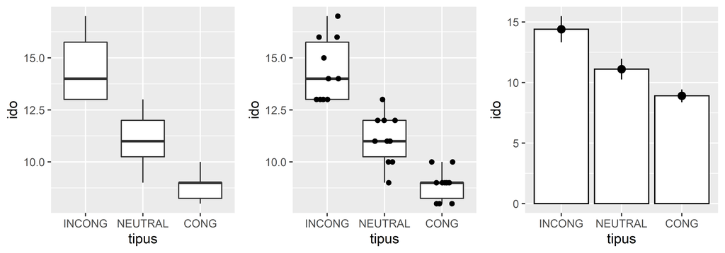

```r
library(ggplot2)
library(gridExtra)
p1 <- ggplot(data = d.long, aes(x = tipus, y = ido)) + geom_boxplot()
p2 <- ggplot(data = d.long, aes(x = tipus, y = ido)) + geom_boxplot() + geom_jitter(height = 0,
    width = 0.2)
p3 <- ggplot(data = d.long, aes(x = tipus, y = ido)) + stat_summary(fun.y = mean,
    geom = "bar", fill = "white", colour = "black") + stat_summary(fun.data = mean_cl_normal,
    geom = "pointrange")
grid.arrange(p1, p2, p3, nrow = 1)
```

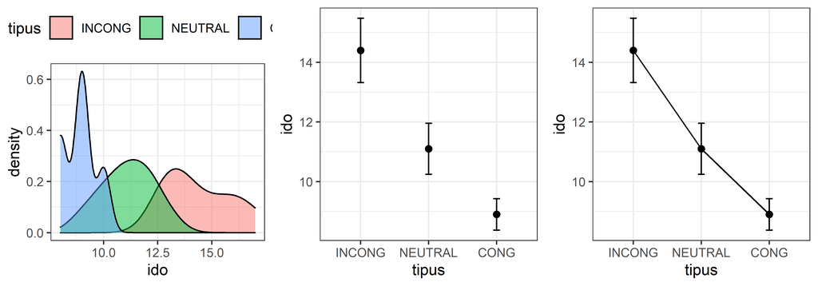

```r
library(ggplot2)
library(gridExtra)

p1 <- ggplot(data = d.long, aes(x = ido, fill = tipus)) + geom_density(alpha = 0.5) +
    theme_bw() + theme(legend.position = "top")

p2 <- ggplot(data = d.long, aes(x = tipus, y = ido)) + stat_summary(fun.y = mean,
    geom = "point", size = 2) + stat_summary(fun.data = mean_cl_normal, geom = "errorbar",
    width = 0.1) + theme_bw()


p3 <- ggplot(data = d.long, aes(x = tipus, y = ido)) + stat_summary(fun.y = mean,
    geom = "point", size = 2) + stat_summary(fun.y = mean, geom = "line", group = 1) +
    stat_summary(fun.data = mean_cl_normal, geom = "errorbar", width = 0.1) + theme_bw()

grid.arrange(p1, p2, p3, nrow = 1)
```

## Előfeltétel vizsgálata

```r
apply(d[1:3], 2, shapiro.test)  # normalitásvizsgálat
```

```
#> $INCONG
#>
#>  Shapiro-Wilk normality test
#>
#> data:  newX[, i]
#> W = 0.85256, p-value = 0.0623
#>
#>
#> $CONG
#>
#>  Shapiro-Wilk normality test
#>
#> data:  newX[, i]
#> W = 0.8325, p-value = 0.03586
#>
#>
#> $NEUTRAL
#>
#>  Shapiro-Wilk normality test
#>
#> data:  newX[, i]
#> W = 0.95194, p-value = 0.6915
```

```r
shapiro.test(d$INCONG)
```

```
#>
#>  Shapiro-Wilk normality test
#>
#> data:  d$INCONG
#> W = 0.85256, p-value = 0.0623
```

```r
shapiro.test(d$CONG)
```

```
#>
#>  Shapiro-Wilk normality test
#>
#> data:  d$CONG
#> W = 0.8325, p-value = 0.03586
```

```r
shapiro.test(d$NEUTRAL)
```

```
#>
#>  Shapiro-Wilk normality test
#>
#> data:  d$NEUTRAL
#> W = 0.95194, p-value = 0.6915
```

```r
by(d.long$ido, d.long$tipus, shapiro.test)
```

```
#> d.long$tipus: INCONG
#>
#>  Shapiro-Wilk normality test
#>
#> data:  dd[x, ]
#> W = 0.85256, p-value = 0.0623
#>
#> ------------------------------------------------------------
#> d.long$tipus: NEUTRAL
#>
#>  Shapiro-Wilk normality test
#>
#> data:  dd[x, ]
#> W = 0.95194, p-value = 0.6915
#>
#> ------------------------------------------------------------
#> d.long$tipus: CONG
#>
#>  Shapiro-Wilk normality test
#>
#> data:  dd[x, ]
#> W = 0.8325, p-value = 0.03586
```

```r
# A szórások egyezőségének vizsgálatának itt a szfericitás vizsgálata felel meg,
# amely az összes mintapár-különbség szórásának egyezőségét jelenti. A lenti
# outputban a szignifikáns Mauchly-próba sértené a szfericitási feltételt.
# Amennyiben a szfericitás sérül, akkor a Greenhouse-Geisser (GG) p értéke
# alapján hozzuk meg a döntésünket (kisebb mintaelemszám esetén a Huynh–Feldt
# /HF/ p értéke alapján.) A közölt epszilon értékek (GGe, HFe), annál kisebbek,
# minél inkább sérül a szferictás.
```

## Próba végrehajtása

```r
library(ez)
d.aov <- ezANOVA(data = d.long, dv = .(ido), within = .(tipus), wid = .(id))
d.aov
```

```
#> $ANOVA
#>   Effect DFn DFd        F                p p<.05       ges
#> 2  tipus   2  18 68.74086 0.00000000373541     * 0.8004875
#>
#> $`Mauchly's Test for Sphericity`
#>   Effect         W         p p<.05
#> 2  tipus 0.8920431 0.6332037
#>
#> $`Sphericity Corrections`
#>   Effect       GGe            p[GG] p[GG]<.05      HFe            p[HF]
#> 2  tipus 0.9025622 0.00000001901849         * 1.115464 0.00000000373541
#>   p[HF]<.05
#> 2         *
```

```r
# utóvizsgálat
pairwise.t.test(x = d.long$ido, g = d.long$tipus, p.adjust.method = "bonf", paired = T)
```

```
#>
#>  Pairwise comparisons using paired t tests
#>
#> data:  d.long$ido and d.long$tipus
#>
#>         INCONG    NEUTRAL
#> NEUTRAL 0.00013   -
#> CONG    0.0000096 0.00151
#>
#> P value adjustment method: bonferroni
```

## Szöveges értékelés

Az egyszempontos összetartozó mintás varianciaelemzés eredménye alapján azt mondhatjuk, elegendő bizonyítékunk van arra, hogy a szólista szignifikáns hatással van a szín felismerésére vonatkozó időre $F(2,18)=68,74;p<0,001; \eta^2_G=0,80$). Az utóvizsgálat eredménye alapján mindhárom csoport szignifikánsan eltér egymástól ($p\leq0,002$).

## Alternatívák

```r
library(jmv)
anovaRM(data = d, rm = list(list(label = "Szolista tipusa", levels = c("inkongruens",
    "kongruens", "semleges"))), rmCells = list(list(measure = "INCONG", cell = "inkongruens"),
    list(measure = "CONG", cell = "kongruens"), list(measure = "NEUTRAL", cell = "semleges")),
    effectSize = c("ges"), rmTerms = ~`Szolista tipusa`, spherTests = TRUE, spherCorr = c("none",
        "GG"), postHoc = list("Szolista tipusa"), postHocCorr = c("bonf"), emmTables = TRUE,
    emmPlotData = TRUE)
```

```
#>
#>  REPEATED MEASURES ANOVA
#>
#>  Within Subjects Effects
#>  ¦¦¦¦¦¦¦¦¦¦¦¦¦¦¦¦¦¦¦¦¦¦¦¦¦¦¦¦¦¦¦¦¦¦¦¦¦¦¦¦¦¦¦¦¦¦¦¦¦¦¦¦¦¦¦¦¦¦¦¦¦¦¦¦¦¦¦¦¦¦¦¦¦¦¦¦¦¦¦¦¦¦¦¦¦¦¦¦¦¦¦¦¦¦¦¦¦¦¦¦¦¦¦¦¦¦¦¦¦¦¦¦¦¦¦¦¦¦¦¦¦¦¦¦¦¦¦¦¦
#>                       Sphericity Correction    Sum of Squares    df           Mean Square    F           p             η2-G
#>  ¦¦¦¦¦¦¦¦¦¦¦¦¦¦¦¦¦¦¦¦¦¦¦¦¦¦¦¦¦¦¦¦¦¦¦¦¦¦¦¦¦¦¦¦¦¦¦¦¦¦¦¦¦¦¦¦¦¦¦¦¦¦¦¦¦¦¦¦¦¦¦¦¦¦¦¦¦¦¦¦¦¦¦¦¦¦¦¦¦¦¦¦¦¦¦¦¦¦¦¦¦¦¦¦¦¦¦¦¦¦¦¦¦¦¦¦¦¦¦¦¦¦¦¦¦¦¦¦¦
#>    Szolista tipusa    None                          153.26667            2      76.633333    68.74086    < .0000001    0.8004875
#>                       Greenhouse-Geisser            153.26667     1.805124      84.906428    68.74086    < .0000001    0.8004875
#>
#>    Residual           None                           20.06667           18       1.114815
#>                       Greenhouse-Geisser             20.06667    16.246120       1.235167
#>  ¦¦¦¦¦¦¦¦¦¦¦¦¦¦¦¦¦¦¦¦¦¦¦¦¦¦¦¦¦¦¦¦¦¦¦¦¦¦¦¦¦¦¦¦¦¦¦¦¦¦¦¦¦¦¦¦¦¦¦¦¦¦¦¦¦¦¦¦¦¦¦¦¦¦¦¦¦¦¦¦¦¦¦¦¦¦¦¦¦¦¦¦¦¦¦¦¦¦¦¦¦¦¦¦¦¦¦¦¦¦¦¦¦¦¦¦¦¦¦¦¦¦¦¦¦¦¦¦¦
#>    Note. Type 3 Sums of Squares
#>
#>
#>  Between Subjects Effects
#>  ¦¦¦¦¦¦¦¦¦¦¦¦¦¦¦¦¦¦¦¦¦¦¦¦¦¦¦¦¦¦¦¦¦¦¦¦¦¦¦¦¦¦¦¦¦¦¦¦¦¦¦¦¦¦¦¦¦¦¦¦¦¦¦¦¦¦¦¦¦¦¦¦¦¦¦¦¦¦¦¦¦¦
#>                Sum of Squares    df    Mean Square    F    p            η2-G
#>  ¦¦¦¦¦¦¦¦¦¦¦¦¦¦¦¦¦¦¦¦¦¦¦¦¦¦¦¦¦¦¦¦¦¦¦¦¦¦¦¦¦¦¦¦¦¦¦¦¦¦¦¦¦¦¦¦¦¦¦¦¦¦¦¦¦¦¦¦¦¦¦¦¦¦¦¦¦¦¦¦¦¦
#>    Residual          18.13333     9       2.014815
#>  ¦¦¦¦¦¦¦¦¦¦¦¦¦¦¦¦¦¦¦¦¦¦¦¦¦¦¦¦¦¦¦¦¦¦¦¦¦¦¦¦¦¦¦¦¦¦¦¦¦¦¦¦¦¦¦¦¦¦¦¦¦¦¦¦¦¦¦¦¦¦¦¦¦¦¦¦¦¦¦¦¦¦
#>    Note. Type 3 Sums of Squares
#>
#>
#>  ASSUMPTIONS
#>
#>  Tests of Sphericity
#>  ¦¦¦¦¦¦¦¦¦¦¦¦¦¦¦¦¦¦¦¦¦¦¦¦¦¦¦¦¦¦¦¦¦¦¦¦¦¦¦¦¦¦¦¦¦¦¦¦¦¦¦¦¦¦¦¦¦¦¦¦¦¦¦¦¦¦¦¦¦¦¦¦¦¦¦¦¦¦¦¦¦¦¦¦¦¦¦¦
#>                       Mauchly's W    p            Greenhouse-Geisser ε    Huynh-Feldt ε
#>  ¦¦¦¦¦¦¦¦¦¦¦¦¦¦¦¦¦¦¦¦¦¦¦¦¦¦¦¦¦¦¦¦¦¦¦¦¦¦¦¦¦¦¦¦¦¦¦¦¦¦¦¦¦¦¦¦¦¦¦¦¦¦¦¦¦¦¦¦¦¦¦¦¦¦¦¦¦¦¦¦¦¦¦¦¦¦¦¦
#>    Szolista tipusa      0.8920431    0.6332037               0.9025622         1.000000
#>  ¦¦¦¦¦¦¦¦¦¦¦¦¦¦¦¦¦¦¦¦¦¦¦¦¦¦¦¦¦¦¦¦¦¦¦¦¦¦¦¦¦¦¦¦¦¦¦¦¦¦¦¦¦¦¦¦¦¦¦¦¦¦¦¦¦¦¦¦¦¦¦¦¦¦¦¦¦¦¦¦¦¦¦¦¦¦¦¦
#>
#>
#>  POST HOC TESTS
#>
#>  Post Hoc Comparisons - Szolista tipusa
#>  ¦¦¦¦¦¦¦¦¦¦¦¦¦¦¦¦¦¦¦¦¦¦¦¦¦¦¦¦¦¦¦¦¦¦¦¦¦¦¦¦¦¦¦¦¦¦¦¦¦¦¦¦¦¦¦¦¦¦¦¦¦¦¦¦¦¦¦¦¦¦¦¦¦¦¦¦¦¦¦¦¦¦¦¦¦¦¦¦¦¦¦¦¦¦¦¦¦¦¦¦¦¦¦¦¦¦¦¦¦¦¦¦¦¦¦¦
#>    Szolista tipusa         Szolista tipusa    Mean Difference    SE           df          t            p-bonferroni
#>  ¦¦¦¦¦¦¦¦¦¦¦¦¦¦¦¦¦¦¦¦¦¦¦¦¦¦¦¦¦¦¦¦¦¦¦¦¦¦¦¦¦¦¦¦¦¦¦¦¦¦¦¦¦¦¦¦¦¦¦¦¦¦¦¦¦¦¦¦¦¦¦¦¦¦¦¦¦¦¦¦¦¦¦¦¦¦¦¦¦¦¦¦¦¦¦¦¦¦¦¦¦¦¦¦¦¦¦¦¦¦¦¦¦¦¦¦
#>    inkongruens        -    kongruens                 5.500000    0.4721895    18.00000    11.647865    < .0000001
#>                       -    semleges                  3.300000    0.4721895    18.00000     6.988719       0.0000048
#>    kongruens          -    semleges                 -2.200000    0.4721895    18.00000    -4.659146       0.0005855
#>  ¦¦¦¦¦¦¦¦¦¦¦¦¦¦¦¦¦¦¦¦¦¦¦¦¦¦¦¦¦¦¦¦¦¦¦¦¦¦¦¦¦¦¦¦¦¦¦¦¦¦¦¦¦¦¦¦¦¦¦¦¦¦¦¦¦¦¦¦¦¦¦¦¦¦¦¦¦¦¦¦¦¦¦¦¦¦¦¦¦¦¦¦¦¦¦¦¦¦¦¦¦¦¦¦¦¦¦¦¦¦¦¦¦¦¦¦
```

# Irodalom

Brace, Nicola, Rosemary Snelgar, and Richard Kemp. 2016. *SPSS for Psychologists: And Everybody Else*. Red Globe Press.